# Risk Factor Analysis

## Outcome Variable

**Outcome Variable:** sstunted

## Predictor Variables

**Intervention Variable:** earlybf

**Adjustment Set:**

- arm
- sex
- W_mage
- meducyrs
- feducyrs
- hhwealth_quart
- hfoodsec
- W_mhtcm
- W_mwtkg
- W_mbmi
- vagbrth
- W_gagebrth
- W_birthwt
- W_birthlen
- W_nrooms
- W_nchldlt5
- brthmon
- W_parity
- impfloor
- impsan
- safeh20
- delta_W_mage
- delta_meducyrs
- delta_feducyrs
- delta_hhwealth_quart
- delta_hfoodsec
- delta_W_mhtcm
- delta_W_mwtkg
- delta_W_mbmi
- delta_vagbrth
- delta_W_gagebrth
- delta_W_birthwt
- delta_W_birthlen
- delta_W_nrooms
- delta_W_nchldlt5
- delta_brthmon
- delta_W_parity
- delta_impfloor
- delta_impsan
- delta_safeh20

## Stratifying Variables

The analysis was stratified on these variable(s):

- agecat
- studyid
- country

## Data Summary

| agecat | studyid | country | earlybf | sstunted | n_cell | n |
| --- | --- | --- | --- | --- | --- | --- |
| Birth | EE | PAKISTAN | 1 | 0 | 38 | 229 |
| Birth | EE | PAKISTAN | 1 | 1 | 6 | 229 |
| Birth | EE | PAKISTAN | 0 | 0 | 145 | 229 |
| Birth | EE | PAKISTAN | 0 | 1 | 40 | 229 |
| Birth | GMS-Nepal | NEPAL | 1 | 0 | 176 | 632 |
| Birth | GMS-Nepal | NEPAL | 1 | 1 | 4 | 632 |
| Birth | GMS-Nepal | NEPAL | 0 | 0 | 431 | 632 |
| Birth | GMS-Nepal | NEPAL | 0 | 1 | 21 | 632 |
| Birth | JiVitA-3 | BANGLADESH | 1 | 0 | 142 | 22370 |
| Birth | JiVitA-3 | BANGLADESH | 1 | 1 | 94 | 22370 |
| Birth | JiVitA-3 | BANGLADESH | 0 | 0 | 19786 | 22370 |
| Birth | JiVitA-3 | BANGLADESH | 0 | 1 | 2348 | 22370 |
| Birth | JiVitA-4 | BANGLADESH | 1 | 0 | 1764 | 2823 |
| Birth | JiVitA-4 | BANGLADESH | 1 | 1 | 148 | 2823 |
| Birth | JiVitA-4 | BANGLADESH | 0 | 0 | 826 | 2823 |
| Birth | JiVitA-4 | BANGLADESH | 0 | 1 | 85 | 2823 |
| Birth | MAL-ED | BANGLADESH | 1 | 0 | 145 | 230 |
| Birth | MAL-ED | BANGLADESH | 1 | 1 | 2 | 230 |
| Birth | MAL-ED | BANGLADESH | 0 | 0 | 76 | 230 |
| Birth | MAL-ED | BANGLADESH | 0 | 1 | 7 | 230 |
| Birth | MAL-ED | BRAZIL | 1 | 0 | 26 | 65 |
| Birth | MAL-ED | BRAZIL | 1 | 1 | 2 | 65 |
| Birth | MAL-ED | BRAZIL | 0 | 0 | 36 | 65 |
| Birth | MAL-ED | BRAZIL | 0 | 1 | 1 | 65 |
| Birth | MAL-ED | INDIA | 1 | 0 | 31 | 46 |
| Birth | MAL-ED | INDIA | 1 | 1 | 1 | 46 |
| Birth | MAL-ED | INDIA | 0 | 0 | 13 | 46 |
| Birth | MAL-ED | INDIA | 0 | 1 | 1 | 46 |
| Birth | MAL-ED | NEPAL | 1 | 0 | 14 | 27 |
| Birth | MAL-ED | NEPAL | 1 | 1 | 0 | 27 |

[output cut: 134 more lines]

The following strata were considered:

- agecat: 24 months, studyid: EE, country: PAKISTAN
- agecat: 24 months, studyid: GMS-Nepal, country: NEPAL
- agecat: 24 months, studyid: JiVitA-3, country: BANGLADESH
- agecat: 24 months, studyid: JiVitA-4, country: BANGLADESH
- agecat: 24 months, studyid: MAL-ED, country: BANGLADESH
- agecat: 24 months, studyid: MAL-ED, country: BRAZIL
- agecat: 24 months, studyid: MAL-ED, country: INDIA
- agecat: 24 months, studyid: MAL-ED, country: NEPAL
- agecat: 24 months, studyid: MAL-ED, country: PERU
- agecat: 24 months, studyid: MAL-ED, country: SOUTH AFRICA
- agecat: 24 months, studyid: MAL-ED, country: TANZANIA, UNITED REPUBLIC OF
- agecat: 24 months, studyid: NIH-Crypto, country: BANGLADESH
- agecat: 24 months, studyid: ZVITAMBO, country: ZIMBABWE
- agecat: 6 months, studyid: EE, country: PAKISTAN
- agecat: 6 months, studyid: GMS-Nepal, country: NEPAL
- agecat: 6 months, studyid: JiVitA-3, country: BANGLADESH
- agecat: 6 months, studyid: JiVitA-4, country: BANGLADESH
- agecat: 6 months, studyid: MAL-ED, country: BANGLADESH
- agecat: 6 months, studyid: MAL-ED, country: BRAZIL
- agecat: 6 months, studyid: MAL-ED, country: INDIA
- agecat: 6 months, studyid: MAL-ED, country: NEPAL
- agecat: 6 months, studyid: MAL-ED, country: PERU
- agecat: 6 months, studyid: MAL-ED, country: SOUTH AFRICA
- agecat: 6 months, studyid: MAL-ED, country: TANZANIA, UNITED REPUBLIC OF
- agecat: 6 months, studyid: NIH-Crypto, country: BANGLADESH
- agecat: 6 months, studyid: SAS-CompFeed, country: INDIA
- agecat: 6 months, studyid: ZVITAMBO, country: ZIMBABWE
- agecat: Birth, studyid: EE, country: PAKISTAN
- agecat: Birth, studyid: GMS-Nepal, country: NEPAL
- agecat: Birth, studyid: JiVitA-3, country: BANGLADESH
- agecat: Birth, studyid: JiVitA-4, country: BANGLADESH
- agecat: Birth, studyid: MAL-ED, country: BANGLADESH
- agecat: Birth, studyid: MAL-ED, country: BRAZIL
- agecat: Birth, studyid: MAL-ED, country: INDIA
- agecat: Birth, studyid: MAL-ED, country: NEPAL
- agecat: Birth, studyid: MAL-ED, country: PERU
- agecat: Birth, studyid: MAL-ED, country: SOUTH AFRICA
- agecat: Birth, studyid: MAL-ED, country: TANZANIA, UNITED REPUBLIC OF
- agecat: Birth, studyid: NIH-Crypto, country: BANGLADESH
- agecat: Birth, studyid: SAS-CompFeed, country: INDIA
- agecat: Birth, studyid: ZVITAMBO, country: ZIMBABWE

### Dropped Strata

Some strata were dropped due to rare outcomes:

- agecat: Birth, studyid: GMS-Nepal, country: NEPAL
- agecat: Birth, studyid: MAL-ED, country: BANGLADESH
- agecat: Birth, studyid: MAL-ED, country: BRAZIL
- agecat: Birth, studyid: MAL-ED, country: INDIA
- agecat: Birth, studyid: MAL-ED, country: NEPAL
- agecat: Birth, studyid: MAL-ED, country: PERU
- agecat: Birth, studyid: MAL-ED, country: SOUTH AFRICA
- agecat: Birth, studyid: MAL-ED, country: TANZANIA, UNITED REPUBLIC OF
- agecat: Birth, studyid: NIH-Crypto, country: BANGLADESH
- agecat: 6 months, studyid: GMS-Nepal, country: NEPAL
- agecat: 6 months, studyid: MAL-ED, country: BANGLADESH
- agecat: 6 months, studyid: MAL-ED, country: BRAZIL
- agecat: 6 months, studyid: MAL-ED, country: INDIA
- agecat: 6 months, studyid: MAL-ED, country: NEPAL
- agecat: 6 months, studyid: MAL-ED, country: PERU
- agecat: 6 months, studyid: MAL-ED, country: SOUTH AFRICA
- agecat: 6 months, studyid: NIH-Crypto, country: BANGLADESH
- agecat: 24 months, studyid: JiVitA-3, country: BANGLADESH
- agecat: 24 months, studyid: MAL-ED, country: BRAZIL
- agecat: 24 months, studyid: MAL-ED, country: NEPAL
- agecat: 24 months, studyid: MAL-ED, country: PERU
- agecat: 24 months, studyid: NIH-Crypto, country: BANGLADESH

## Methods Detail

We’re interested in the causal parameters $E[Y_a]$ for all values of $a \in \mathcal{A}$. These parameters represent the mean outcome if, possibly contrary to fact, we intervened to set all units to have $A=a$. Under the randomization and positivity assumptions, these are identified by the statistical parameters $\psi_a=E_W[E_{Y|A,W}(Y|A=a,W)]$. In addition, we’re interested in the mean of $Y$, $E[Y]$ under no intervention (the observed mean). We will estimate these parameters by using SuperLearner to fit the relevant likelihood factors – $E_{Y|A,W}(Y|A=a,W)$ and $p(A=a|W)$, and then updating our likelihood fit using a joint TMLE.

For unadjusted analyses ($W=\{\}$), initial likelihoods were estimated using Lrnr_glm to estimate the simple $E(Y|A)$ and Lrnr_mean to estimate $p(A)$. For adjusted analyses, a small library containing Lrnr_glmnet, Lrnr_xgboost, and Lrnr_mean was used.

Having estimated these parameters, we will then use the delta method to estimate relative risks and attributable risks relative to a prespecified baseline level of $A$.

# Results Detail

## Results Plots

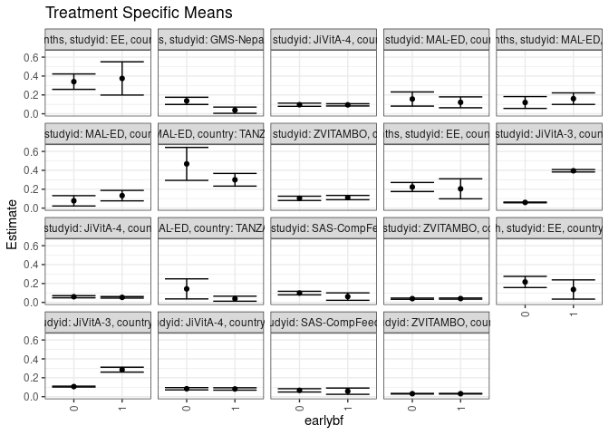

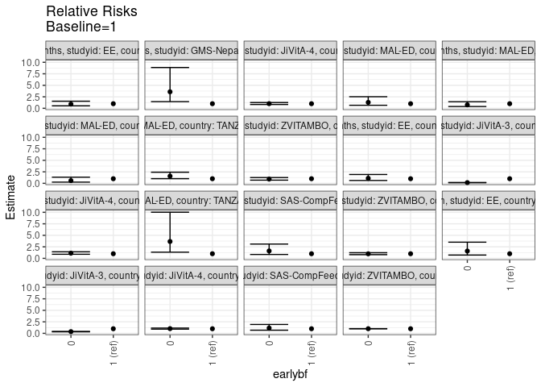

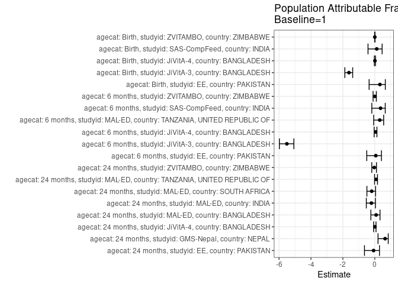

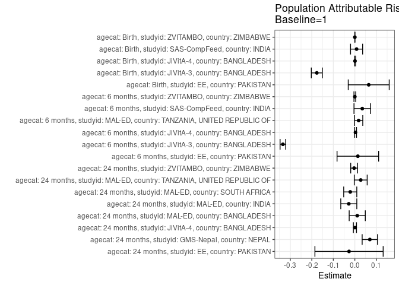

## Results Table

### Parameter: TSM

| agecat | studyid | country | intervention_level | baseline_level | estimate | ci_lower | ci_upper |
| --- | --- | --- | --- | --- | --- | --- | --- |
| Birth | EE | PAKISTAN | 1 | NA | 0.1363636 | 0.0347419 | 0.2379854 |
| Birth | EE | PAKISTAN | 0 | NA | 0.2162162 | 0.1567658 | 0.2756666 |
| Birth | JiVitA-3 | BANGLADESH | 1 | NA | 0.2859035 | 0.2600212 | 0.3117858 |
| Birth | JiVitA-3 | BANGLADESH | 0 | NA | 0.1067056 | 0.1020924 | 0.1113188 |
| Birth | JiVitA-4 | BANGLADESH | 1 | NA | 0.0817630 | 0.0691968 | 0.0943291 |
| Birth | JiVitA-4 | BANGLADESH | 0 | NA | 0.0836698 | 0.0714333 | 0.0959063 |
| Birth | SAS-CompFeed | INDIA | 1 | NA | 0.0581395 | 0.0251640 | 0.0911151 |
| Birth | SAS-CompFeed | INDIA | 0 | NA | 0.0669045 | 0.0492927 | 0.0845164 |
| Birth | ZVITAMBO | ZIMBABWE | 1 | NA | 0.0311561 | 0.0280864 | 0.0342258 |
| Birth | ZVITAMBO | ZIMBABWE | 0 | NA | 0.0314378 | 0.0283422 | 0.0345333 |
| 6 months | EE | PAKISTAN | 1 | NA | 0.2042693 | 0.0984261 | 0.3101124 |
| 6 months | EE | PAKISTAN | 0 | NA | 0.2232339 | 0.1755109 | 0.2709569 |
| 6 months | JiVitA-3 | BANGLADESH | 1 | NA | 0.3949210 | 0.3821533 | 0.4076886 |
| 6 months | JiVitA-3 | BANGLADESH | 0 | NA | 0.0599726 | 0.0560378 | 0.0639074 |
| 6 months | JiVitA-4 | BANGLADESH | 1 | NA | 0.0532274 | 0.0450420 | 0.0614127 |
| 6 months | JiVitA-4 | BANGLADESH | 0 | NA | 0.0598207 | 0.0486476 | 0.0709938 |
| 6 months | MAL-ED | TANZANIA, UNITED REPUBLIC OF | 1 | NA | 0.0390244 | 0.0124614 | 0.0655873 |
| 6 months | MAL-ED | TANZANIA, UNITED REPUBLIC OF | 0 | NA | 0.1428571 | 0.0368142 | 0.2489001 |
| 6 months | SAS-CompFeed | INDIA | 1 | NA | 0.0612245 | 0.0218241 | 0.1006248 |
| 6 months | SAS-CompFeed | INDIA | 0 | NA | 0.0985460 | 0.0798882 | 0.1172039 |
| 6 months | ZVITAMBO | ZIMBABWE | 1 | NA | 0.0400995 | 0.0342135 | 0.0459856 |
| 6 months | ZVITAMBO | ZIMBABWE | 0 | NA | 0.0394446 | 0.0331419 | 0.0457474 |
| 24 months | EE | PAKISTAN | 1 | NA | 0.3745074 | 0.1985877 | 0.5504271 |
| 24 months | EE | PAKISTAN | 0 | NA | 0.3403251 | 0.2587761 | 0.4218740 |
| 24 months | GMS-Nepal | NEPAL | 1 | NA | 0.0381679 | 0.0053206 | 0.0710153 |
| 24 months | GMS-Nepal | NEPAL | 0 | NA | 0.1369427 | 0.0988746 | 0.1750108 |
| 24 months | JiVitA-4 | BANGLADESH | 1 | NA | 0.0948678 | 0.0830153 | 0.1067203 |
| 24 months | JiVitA-4 | BANGLADESH | 0 | NA | 0.0960987 | 0.0796292 | 0.1125683 |
| 24 months | MAL-ED | BANGLADESH | 1 | NA | 0.1215331 | 0.0637096 | 0.1793565 |
| 24 months | MAL-ED | BANGLADESH | 0 | NA | 0.1565122 | 0.0816851 | 0.2313393 |
| 24 months | MAL-ED | INDIA | 1 | NA | 0.1602476 | 0.0991577 | 0.2213375 |
| 24 months | MAL-ED | INDIA | 0 | NA | 0.1197981 | 0.0570819 | 0.1825143 |
| 24 months | MAL-ED | SOUTH AFRICA | 1 | NA | 0.1319444 | 0.0765505 | 0.1873384 |
| 24 months | MAL-ED | SOUTH AFRICA | 0 | NA | 0.0769231 | 0.0220574 | 0.1317887 |
| 24 months | MAL-ED | TANZANIA, UNITED REPUBLIC OF | 1 | NA | 0.2997663 | 0.2325687 | 0.3669639 |
| 24 months | MAL-ED | TANZANIA, UNITED REPUBLIC OF | 0 | NA | 0.4679223 | 0.2934916 | 0.6423530 |
| 24 months | ZVITAMBO | ZIMBABWE | 1 | NA | 0.1114131 | 0.0885709 | 0.1342553 |
| 24 months | ZVITAMBO | ZIMBABWE | 0 | NA | 0.1033022 | 0.0806300 | 0.1259743 |

### Parameter: E(Y)

| agecat | studyid | country | intervention_level | baseline_level | estimate | ci_lower | ci_upper |
| --- | --- | --- | --- | --- | --- | --- | --- |
| Birth | EE | PAKISTAN | NA | NA | 0.2008734 | 0.1488678 | 0.2528789 |
| Birth | JiVitA-3 | BANGLADESH | NA | NA | 0.1091641 | 0.1046058 | 0.1137223 |
| Birth | JiVitA-4 | BANGLADESH | NA | NA | 0.0825363 | 0.0708486 | 0.0942240 |
| Birth | SAS-CompFeed | INDIA | NA | NA | 0.0662800 | 0.0486880 | 0.0838721 |
| Birth | ZVITAMBO | ZIMBABWE | NA | NA | 0.0312449 | 0.0281769 | 0.0343130 |
| 6 months | EE | PAKISTAN | NA | NA | 0.2182320 | 0.1756239 | 0.2608402 |
| 6 months | JiVitA-3 | BANGLADESH | NA | NA | 0.0606746 | 0.0568229 | 0.0645262 |
| 6 months | JiVitA-4 | BANGLADESH | NA | NA | 0.0560960 | 0.0493335 | 0.0628586 |
| 6 months | MAL-ED | TANZANIA, UNITED REPUBLIC OF | NA | NA | 0.0566802 | 0.0277850 | 0.0855754 |
| 6 months | SAS-CompFeed | INDIA | NA | NA | 0.0958084 | 0.0774939 | 0.1141229 |
| 6 months | ZVITAMBO | ZIMBABWE | NA | NA | 0.0401403 | 0.0357552 | 0.0445254 |
| 24 months | EE | PAKISTAN | NA | NA | 0.3475610 | 0.2744572 | 0.4206647 |
| 24 months | GMS-Nepal | NEPAL | NA | NA | 0.1078652 | 0.0790107 | 0.1367196 |
| 24 months | JiVitA-4 | BANGLADESH | NA | NA | 0.0953283 | 0.0857752 | 0.1048814 |
| 24 months | MAL-ED | BANGLADESH | NA | NA | 0.1327014 | 0.0868175 | 0.1785853 |
| 24 months | MAL-ED | INDIA | NA | NA | 0.1321586 | 0.0880054 | 0.1763117 |
| 24 months | MAL-ED | SOUTH AFRICA | NA | NA | 0.1106383 | 0.0704470 | 0.1508296 |
| 24 months | MAL-ED | TANZANIA, UNITED REPUBLIC OF | NA | NA | 0.3271028 | 0.2640978 | 0.3901078 |
| 24 months | ZVITAMBO | ZIMBABWE | NA | NA | 0.1081081 | 0.0918715 | 0.1243447 |

### Parameter: RR

| agecat | studyid | country | intervention_level | baseline_level | estimate | ci_lower | ci_upper |
| --- | --- | --- | --- | --- | --- | --- | --- |
| Birth | EE | PAKISTAN | 1 | 1 | 1.0000000 | 1.0000000 | 1.0000000 |
| Birth | EE | PAKISTAN | 0 | 1 | 1.5855856 | 0.7164987 | 3.5088434 |
| Birth | JiVitA-3 | BANGLADESH | 1 | 1 | 1.0000000 | 1.0000000 | 1.0000000 |
| Birth | JiVitA-3 | BANGLADESH | 0 | 1 | 0.3732224 | 0.3376903 | 0.4124933 |
| Birth | JiVitA-4 | BANGLADESH | 1 | 1 | 1.0000000 | 1.0000000 | 1.0000000 |
| Birth | JiVitA-4 | BANGLADESH | 0 | 1 | 1.0233214 | 0.9126183 | 1.1474532 |
| Birth | SAS-CompFeed | INDIA | 1 | 1 | 1.0000000 | 1.0000000 | 1.0000000 |
| Birth | SAS-CompFeed | INDIA | 0 | 1 | 1.1507583 | 0.6866757 | 1.9284861 |
| Birth | ZVITAMBO | ZIMBABWE | 1 | 1 | 1.0000000 | 1.0000000 | 1.0000000 |
| Birth | ZVITAMBO | ZIMBABWE | 0 | 1 | 1.0090408 | 0.9942708 | 1.0240303 |
| 6 months | EE | PAKISTAN | 1 | 1 | 1.0000000 | 1.0000000 | 1.0000000 |
| 6 months | EE | PAKISTAN | 0 | 1 | 1.0928412 | 0.6235456 | 1.9153402 |
| 6 months | JiVitA-3 | BANGLADESH | 1 | 1 | 1.0000000 | 1.0000000 | 1.0000000 |
| 6 months | JiVitA-3 | BANGLADESH | 0 | 1 | 0.1518597 | 0.1410187 | 0.1635342 |
| 6 months | JiVitA-4 | BANGLADESH | 1 | 1 | 1.0000000 | 1.0000000 | 1.0000000 |
| 6 months | JiVitA-4 | BANGLADESH | 0 | 1 | 1.1238702 | 0.8868866 | 1.4241778 |
| 6 months | MAL-ED | TANZANIA, UNITED REPUBLIC OF | 1 | 1 | 1.0000000 | 1.0000000 | 1.0000000 |
| 6 months | MAL-ED | TANZANIA, UNITED REPUBLIC OF | 0 | 1 | 3.6607143 | 1.3371210 | 10.0221514 |
| 6 months | SAS-CompFeed | INDIA | 1 | 1 | 1.0000000 | 1.0000000 | 1.0000000 |
| 6 months | SAS-CompFeed | INDIA | 0 | 1 | 1.6095854 | 0.8339140 | 3.1067532 |
| 6 months | ZVITAMBO | ZIMBABWE | 1 | 1 | 1.0000000 | 1.0000000 | 1.0000000 |
| 6 months | ZVITAMBO | ZIMBABWE | 0 | 1 | 0.9836678 | 0.7954579 | 1.2164091 |
| 24 months | EE | PAKISTAN | 1 | 1 | 1.0000000 | 1.0000000 | 1.0000000 |
| 24 months | EE | PAKISTAN | 0 | 1 | 0.9087273 | 0.5358100 | 1.5411904 |
| 24 months | GMS-Nepal | NEPAL | 1 | 1 | 1.0000000 | 1.0000000 | 1.0000000 |
| 24 months | GMS-Nepal | NEPAL | 0 | 1 | 3.5878981 | 1.4523514 | 8.8635661 |
| 24 months | JiVitA-4 | BANGLADESH | 1 | 1 | 1.0000000 | 1.0000000 | 1.0000000 |
| 24 months | JiVitA-4 | BANGLADESH | 0 | 1 | 1.0129750 | 0.8208658 | 1.2500440 |
| 24 months | MAL-ED | BANGLADESH | 1 | 1 | 1.0000000 | 1.0000000 | 1.0000000 |
| 24 months | MAL-ED | BANGLADESH | 0 | 1 | 1.2878157 | 0.6588566 | 2.5171929 |
| 24 months | MAL-ED | INDIA | 1 | 1 | 1.0000000 | 1.0000000 | 1.0000000 |
| 24 months | MAL-ED | INDIA | 0 | 1 | 0.7475811 | 0.3898326 | 1.4336348 |
| 24 months | MAL-ED | SOUTH AFRICA | 1 | 1 | 1.0000000 | 1.0000000 | 1.0000000 |
| 24 months | MAL-ED | SOUTH AFRICA | 0 | 1 | 0.5829960 | 0.2548159 | 1.3338424 |
| 24 months | MAL-ED | TANZANIA, UNITED REPUBLIC OF | 1 | 1 | 1.0000000 | 1.0000000 | 1.0000000 |
| 24 months | MAL-ED | TANZANIA, UNITED REPUBLIC OF | 0 | 1 | 1.5609570 | 1.0102683 | 2.4118214 |
| 24 months | ZVITAMBO | ZIMBABWE | 1 | 1 | 1.0000000 | 1.0000000 | 1.0000000 |
| 24 months | ZVITAMBO | ZIMBABWE | 0 | 1 | 0.9271996 | 0.6881828 | 1.2492307 |

### Parameter: PAR

| agecat | studyid | country | intervention_level | baseline_level | estimate | ci_lower | ci_upper |
| --- | --- | --- | --- | --- | --- | --- | --- |
| Birth | EE | PAKISTAN | 1 | NA | 0.0645097 | -0.0306907 | 0.1597101 |
| Birth | JiVitA-3 | BANGLADESH | 1 | NA | -0.1767395 | -0.2023194 | -0.1511595 |
| Birth | JiVitA-4 | BANGLADESH | 1 | NA | 0.0007733 | -0.0022438 | 0.0037905 |
| Birth | SAS-CompFeed | INDIA | 1 | NA | 0.0081405 | -0.0199419 | 0.0362229 |
| Birth | ZVITAMBO | ZIMBABWE | 1 | NA | 0.0000889 | -0.0001656 | 0.0003433 |
| 6 months | EE | PAKISTAN | 1 | NA | 0.0139628 | -0.0826944 | 0.1106200 |
| 6 months | JiVitA-3 | BANGLADESH | 1 | NA | -0.3342464 | -0.3473812 | -0.3211116 |
| 6 months | JiVitA-4 | BANGLADESH | 1 | NA | 0.0028686 | -0.0020330 | 0.0077703 |
| 6 months | MAL-ED | TANZANIA, UNITED REPUBLIC OF | 1 | NA | 0.0176558 | -0.0015614 | 0.0368729 |
| 6 months | SAS-CompFeed | INDIA | 1 | NA | 0.0345839 | -0.0039983 | 0.0731661 |
| 6 months | ZVITAMBO | ZIMBABWE | 1 | NA | 0.0000408 | -0.0040741 | 0.0041556 |
| 24 months | EE | PAKISTAN | 1 | NA | -0.0269464 | -0.1855189 | 0.1316261 |
| 24 months | GMS-Nepal | NEPAL | 1 | NA | 0.0696972 | 0.0339722 | 0.1054223 |
| 24 months | JiVitA-4 | BANGLADESH | 1 | NA | 0.0004605 | -0.0067922 | 0.0077132 |
| 24 months | MAL-ED | BANGLADESH | 1 | NA | 0.0111683 | -0.0262691 | 0.0486058 |
| 24 months | MAL-ED | INDIA | 1 | NA | -0.0280890 | -0.0653192 | 0.0091411 |
| 24 months | MAL-ED | SOUTH AFRICA | 1 | NA | -0.0213061 | -0.0516920 | 0.0090797 |
| 24 months | MAL-ED | TANZANIA, UNITED REPUBLIC OF | 1 | NA | 0.0273365 | -0.0026712 | 0.0573442 |
| 24 months | ZVITAMBO | ZIMBABWE | 1 | NA | -0.0033050 | -0.0191029 | 0.0124930 |

### Parameter: PAF

| agecat | studyid | country | intervention_level | baseline_level | estimate | ci_lower | ci_upper |
| --- | --- | --- | --- | --- | --- | --- | --- |
| Birth | EE | PAKISTAN | 1 | NA | 0.3211462 | -0.3548268 | 0.6598514 |
| Birth | JiVitA-3 | BANGLADESH | 1 | NA | -1.6190261 | -1.8762159 | -1.3848340 |
| Birth | JiVitA-4 | BANGLADESH | 1 | NA | 0.0093696 | -0.0281308 | 0.0455022 |
| Birth | SAS-CompFeed | INDIA | 1 | NA | 0.1228198 | -0.4233308 | 0.4594052 |
| Birth | ZVITAMBO | ZIMBABWE | 1 | NA | 0.0028438 | -0.0053276 | 0.0109487 |
| 6 months | EE | PAKISTAN | 1 | NA | 0.0639813 | -0.5027940 | 0.4169986 |
| 6 months | JiVitA-3 | BANGLADESH | 1 | NA | -5.5088397 | -5.9784219 | -5.0708559 |
| 6 months | JiVitA-4 | BANGLADESH | 1 | NA | 0.0511381 | -0.0403481 | 0.1345793 |
| 6 months | MAL-ED | TANZANIA, UNITED REPUBLIC OF | 1 | NA | 0.3114983 | -0.0691645 | 0.5566308 |
| 6 months | SAS-CompFeed | INDIA | 1 | NA | 0.3609694 | -0.1862100 | 0.6557438 |
| 6 months | ZVITAMBO | ZIMBABWE | 1 | NA | 0.0010155 | -0.1069353 | 0.0984387 |
| 24 months | EE | PAKISTAN | 1 | NA | -0.0775301 | -0.6455240 | 0.2944065 |
| 24 months | GMS-Nepal | NEPAL | 1 | NA | 0.6461514 | 0.2037010 | 0.8427615 |
| 24 months | JiVitA-4 | BANGLADESH | 1 | NA | 0.0048304 | -0.0742234 | 0.0780665 |
| 24 months | MAL-ED | BANGLADESH | 1 | NA | 0.0841615 | -0.2463954 | 0.3270513 |
| 24 months | MAL-ED | INDIA | 1 | NA | -0.2125402 | -0.5301503 | 0.0391442 |
| 24 months | MAL-ED | SOUTH AFRICA | 1 | NA | -0.1925748 | -0.4934545 | 0.0476880 |
| 24 months | MAL-ED | TANZANIA, UNITED REPUBLIC OF | 1 | NA | 0.0835716 | -0.0128074 | 0.1707792 |
| 24 months | ZVITAMBO | ZIMBABWE | 1 | NA | -0.0305709 | -0.1875644 | 0.1056684 |